# Data Wrangling Project

April 17, 2018

## An Explanation

- The idea behind this project was to see if the happiness ranking of a country as given by the 2017 Gallup poll was reflected in the happiness of the major literary works from that country
- Did unhappier countries produce unhappier authors who wrote unhappier books?
- Did countries differ in the types of words they used?
- i.e. Would a country higher in happiness rank tend to write books with more joy and trust words as opposed to fear and disgust words?

## The Happiest Places

| Happiness.Rank | Country | Region | Happiness.Score |
| --- | --- | --- | --- |
| 1 | Norway | Western Europe | 7.537 |
| 2 | Denmark | Western Europe | 7.522 |
| 3 | Iceland | Western Europe | 7.504 |
| 4 | Switzerland | Western Europe | 7.494 |
| 5 | Finland | Western Europe | 7.469 |

## The Unhappiest Places

| Happiness.Rank | Country | Region | Happiness.Score |
| --- | --- | --- | --- |
| 151 | Rwanda | Sub-Saharan Africa | 3.471 |
| 152 | Syria | Middle East and Northern Africa | 3.462 |
| 153 | Tanzania | Sub-Saharan Africa | 3.349 |
| 154 | Burundi | Sub-Saharan Africa | 2.905 |
| 155 | Central African Republic | NA | 2.693 |

## Top 10 Countries

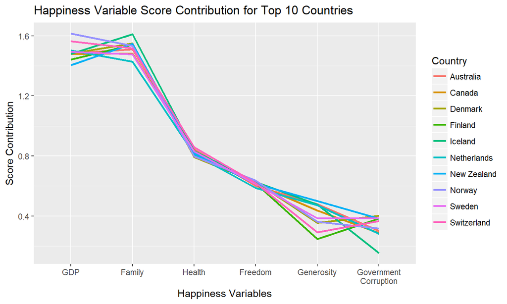

## Bottom 10 Countries

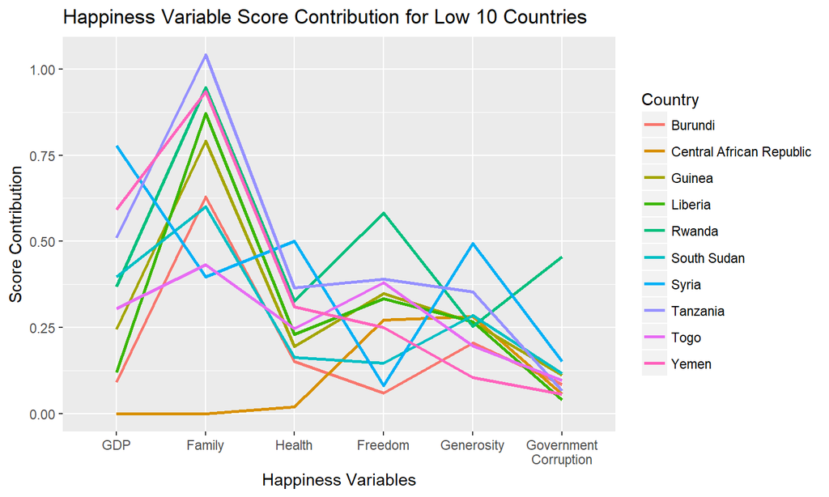

## Happiness By Region

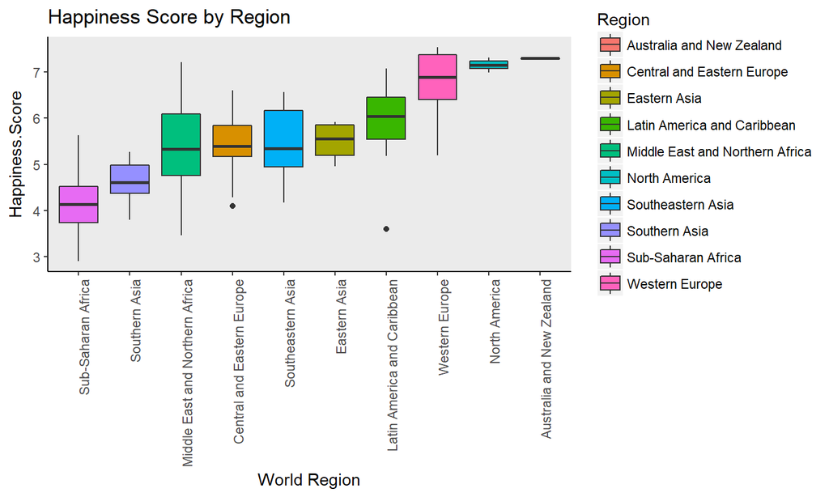

## Happiness Variables by World Region

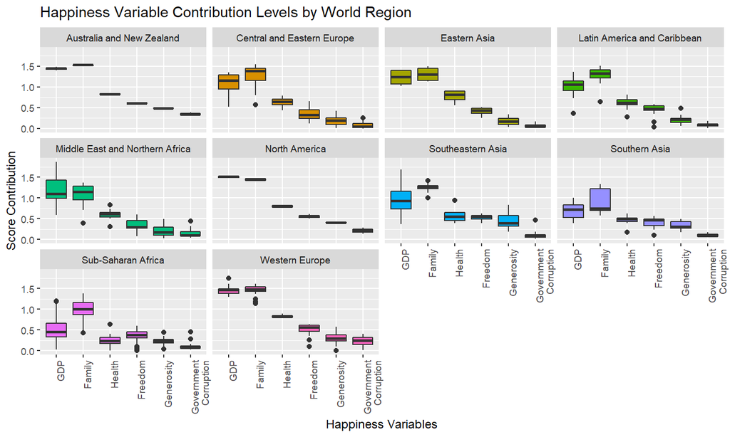

## Countries Overview

The next part of the report focuses on the happiness and literary analysis of our 5 selected countries. First, we examine their happiness rankings to get a general picture of their overall happiness.

```
## # A tibble: 5 x 9
##   Happiness.Rank Country       Happiness.Score   GDP Family Health Freedom
##            <int> <chr>                   <dbl> <dbl>  <dbl>  <dbl>   <dbl>
## 1             14 United States            6.99  1.55   1.42  0.774  0.506
## 2             19 United Kingd~            6.71  1.44   1.50  0.805  0.508
## 3             31 France                   6.44  1.43   1.39  0.844  0.470
## 4             49 Russia                   5.96  1.28   1.47  0.547  0.374
## 5             87 Greece                   5.23  1.29   1.24  0.810  0.0957
## # ... with 2 more variables: Generosity <dbl>, `Government
## #   Corruption` <dbl>
```

## Happiness Variable Contributions

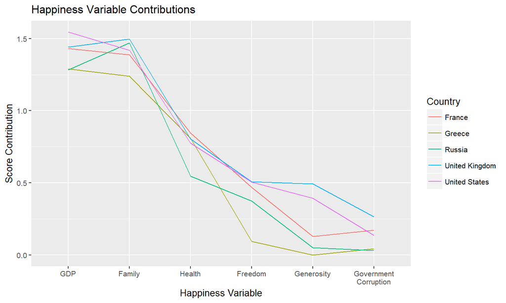

## Method - part 1

- For each of the five countries examined I scraped the Wikipedia pages of 20-30 of its most prominent authors. I then scored the pages using the AFINN lexicon for its positive vs negative sentiment. I reasoned authors with more negative biographies, probably led unhappier lives. Conversely, those with more positive biographies led happier lives. I assigned each author a "Mean Bio Score"
- I then used the R-Gutenberg package to score the major literary works of these authors using both the AFINN and NRC lexicons and assigned each author a Mean Book Score for the overall positivity/negativity of their body of work.
- Finally, I joined the "Mean Bio Scores", "Mean Book Scores" and "NRC Scores" on author into one large table. The table required some light regex cleaning to deal with the accents in some of the authors' name.

## Method - part 2

- The NRC lexicon was used to find the proportion of words used by each author corresponding to emotions like joy and fear.
- The AFINN lexicon was used since it applies a score to words ranging from -5 to 5. I found this lexicon more nuanced than the BING lexicon which simply categorizes words into 1 or -1 scores. For example, with BING, the phrase tortured and exiled would receive the same negative score as unhappy and sad childhood which I did not think was adequate.

## Literary Analysis

- Now we can look at some plots and see if there are any relationships between the happiness of an author, and the overall sentiment of their work. We will also examine whether an author's native country's happiness is related to their own happiness, as well as the overall sentiment of their work.

## Mean Book Score vs Mean Bio Score

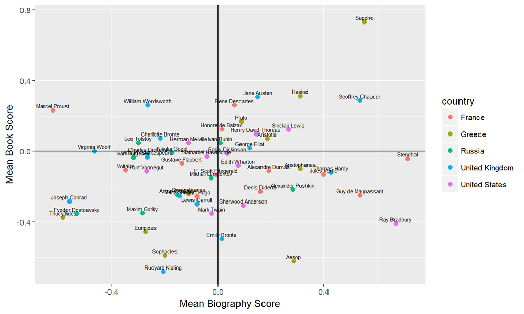

## Authors Happiness by Country

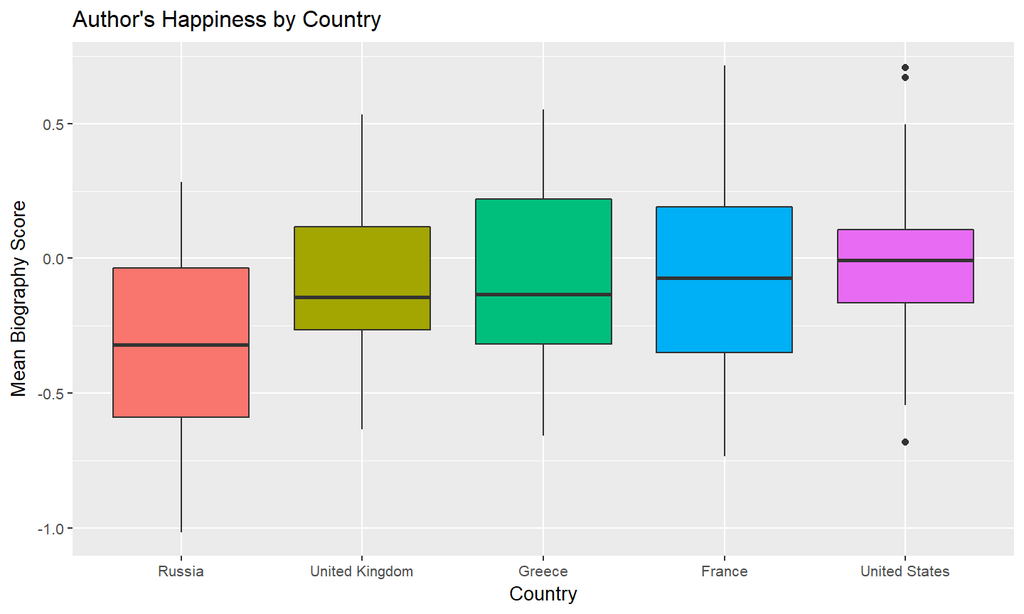

## Average Book Sentiment by Country

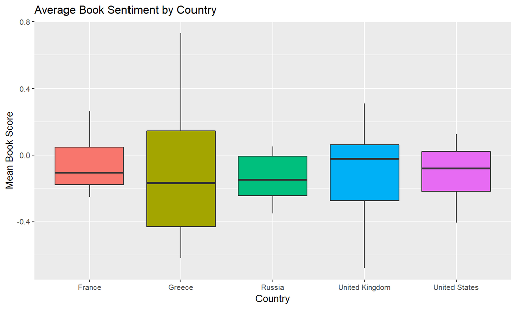

## NRC Analysis

- Now I examine how each country and the authors from those countries differed in their use of NRC words like "joy", "surprise", "anger" etc. I had hoped for a pattern to emerge, like American authors used more "pride" word on average than other countries. However, what emerged was the fact that the proportion of NRC emotion words used by each country was about the same.
- To perform these analyses, I had to gather the NRC variables in my authors_and_bios table in order to be able to plot them all together.

## NRC Words by Country

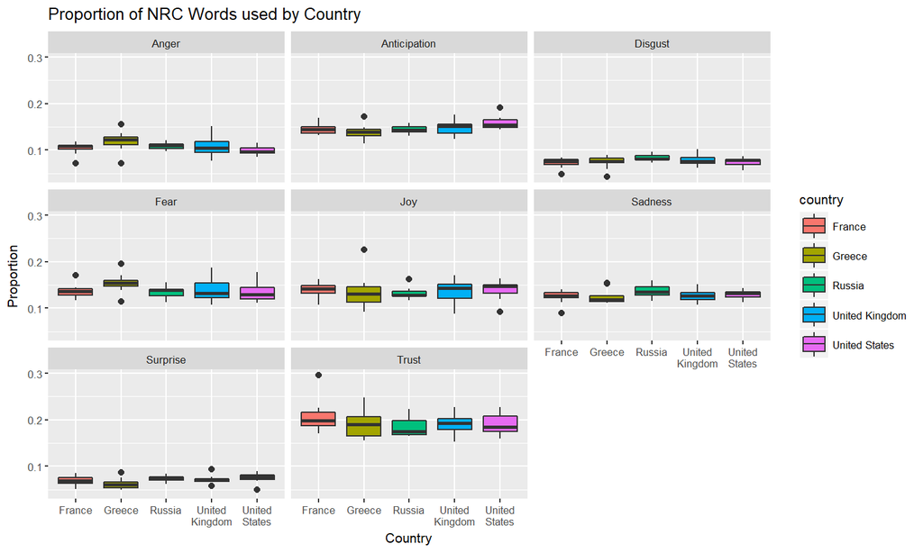

## NRC Emotions by Russian Authors

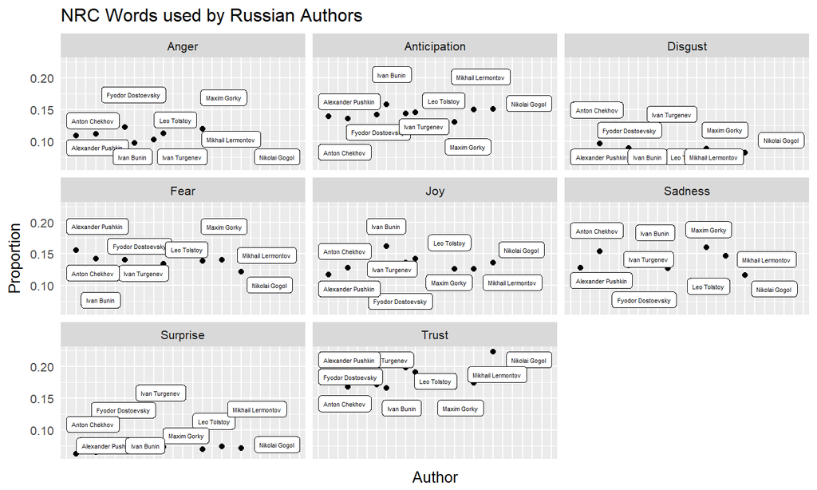

## NRC Emotions by British Authors

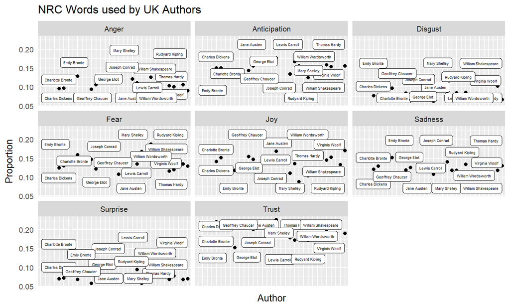

## NRC Emotions by French Authors

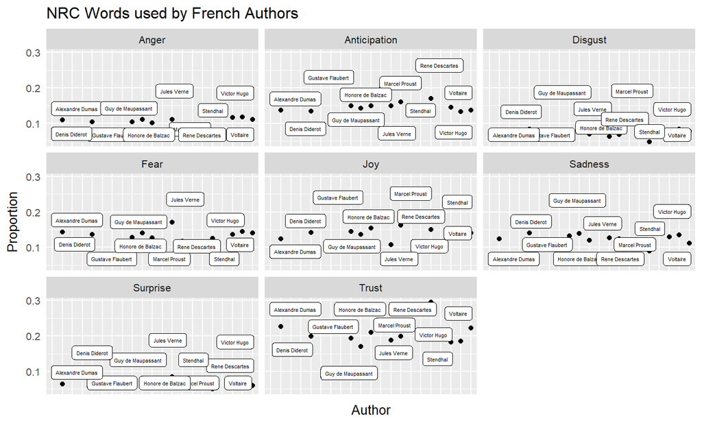

## NRC Emotions by Greek Authors

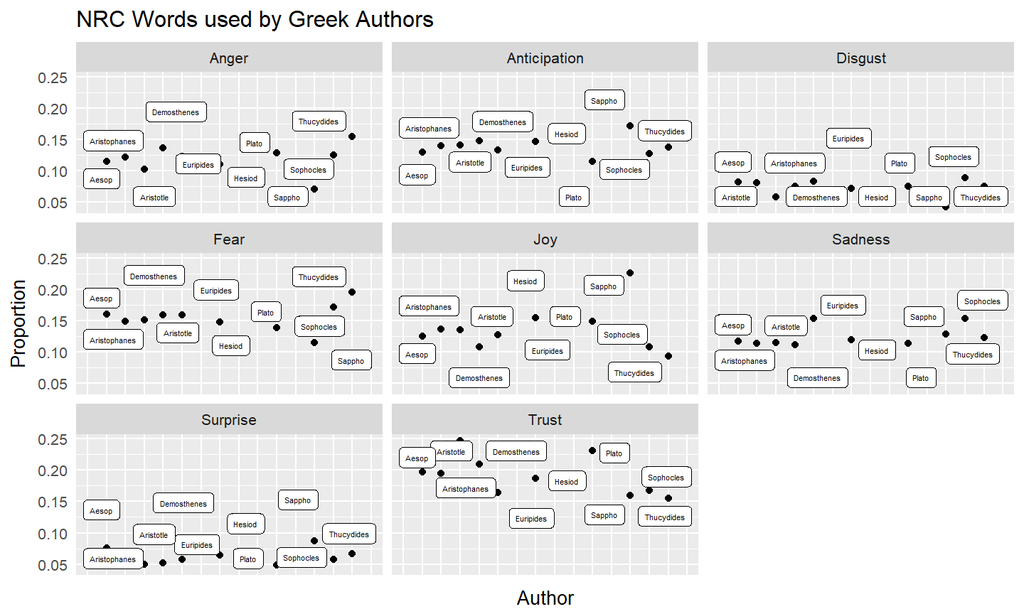

## NRC Emotions by American Authors

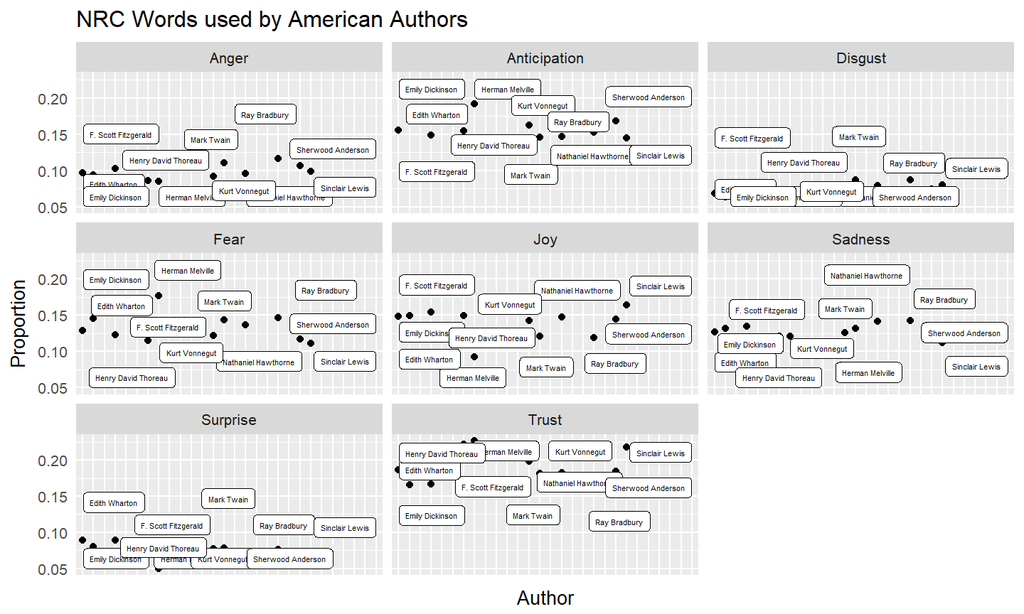